# Project 2: Modeling, Testing, and Predicting

SDS348

# Lily Tapia (lmt2622)

## Guidelines and Rubric

- **0. (5 pts)** Introduce your dataset and each of your variables (or just your main variables if you have lots) in a paragraph. What are they measuring? How many observations?

My dataset, ‘CollegeDistance’, involves data from a survey conducted by the Department of Education in 1980. There is a total of 14 variables of this dataset and 4739 observations. There are 8 categorical variables which include ‘gender’, ‘ethnicity’, ‘fcollege’ (if the student’s father was a college grad), ‘mcollege’ (if student’s mom was a college grad), ‘home’ (whether or not the family owns a home), ‘urban’ (if the school is in an urban area),‘income’ (if family income is above $25,000/year) and ‘region’ (West region or other). There are 6 total numeric variables which include the base year composite ‘score’ of high school seniors, ‘unemp’ which represents county unemployment rate in 1980, ‘wage’ (state hourly wage in manufacturing), ‘distance’ (distance from 4-year college), ‘tuition’ (average state tuition of 4-year college), and ‘education’ (years of education).

The code used to read and summarize the data is shown below.

```r
library(tidyverse)
library(dplyr)
library(readr)
CollegeDistance <- read_csv("~/CollegeDistance.csv")
CollegeDistance$X1<-NULL
summary(CollegeDistance) #summarize CollegeDistnace dataset
```

```
## gender ethnicity score fcollege mcollege
## Length:4739 Length:4739 Min.  :28.95 Length:4739
Length:4739
## Class :character Class :character 1st Qu.:43.92 Class
:character Class :character
## Mode :character Mode :character Median :51.19 Mode
:character Mode :character
## Mean :50.89
## 3rd Qu.:57.77
## Max.  :72.81
## home urban unemp wage distance
## Length:4739 Length:4739 Min.  : 1.400 Min.  : 6.590 Min.
: 0.000
## Class :character Class :character 1st Qu.: 5.900 1st
Qu.: 8.850 1st Qu.: 0.400
## Mode :character Mode :character Median : 7.100 Median :
9.680 Median : 1.000
## Mean : 7.597 Mean : 9.501 Mean : 1.803
## 3rd Qu.: 8.900 3rd Qu.:10.150 3rd Qu.: 2.500
## Max.  :24.900 Max.  :12.960 Max.  :20.000
## tuition education income region
## Min.  :0.2575 Min.  :12.00 Length:4739 Length:4739
## 1st Qu.:0.4850 1st Qu.:12.00 Class :character Class
:character
## Median :0.8245 Median :13.00 Mode :character Mode
:character
## Mean :0.8146 Mean :13.81
## 3rd Qu.:1.1270 3rd Qu.:16.00
## Max.  :1.4042 Max.  :18.00
```

- **1. (15 pts)** Perform a MANOVA testing whether any of your numeric variables (or a subset of them, if including them all is unreasonable or doesn’t make sense) show a mean difference across levels of one of your categorical variables (3). If they do, perform univariate ANOVAs to find response(s) showing a mean difference across groups (3), and perform post-hoc t tests to find which groups differ (3). Discuss the number of tests you have performed, calculate the probability of at least one type I error (if unadjusted), and adjust the significance level accordingly (bonferroni correction) before discussing significant differences (3). Briefly discuss some of the MANOVA assumptions and whether or not they are likely to have been met here (no need for anything too in-depth) (2).

Some MANOVA assumptions include random samples/independent observations, multivariate normality of DVs, and homogeneity of within-group covariance matrices; it is not likely that these assumptions have been met, as the hypothesis tests for homogeneity and for multivariate normality resulted in p-values below 0.05, indicating that the null hypotheses (assumption for homogeneity and multivariate normality) were not met.

```r
#MANOVA
mancollege <- manova(cbind(score, unemp, wage, distance, tuition, education)~gender, data=CollegeDistance)
summary(mancollege)
```

```
## Df Pillai approx F num Df den Df Pr(>F)
## gender 1 0.0088288 7.025 6 4732 1.855e-07 ***
## Residuals 4737
## ---
## Signif. codes: 0 '***' 0.001 '**' 0.01 '*' 0.05 '.' 0.1
' ' 1
```

```r
#univariate ANOVAs
summary.aov(mancollege)
```

```
## Response score :
## Df Sum Sq Mean Sq F value Pr(>F)
## gender 1 2306 2305.89 30.642 3.27e-08 ***
## Residuals 4737 356471 75.25
## ---
## Signif. codes: 0 '***' 0.001 '**' 0.01 '*' 0.05 '.' 0.1
' ' 1
##
## Response unemp :
## Df Sum Sq Mean Sq F value Pr(>F)
## gender 1 29 29.1457 3.8185 0.05075 .
## Residuals 4737 36157 7.6328
## ---
## Signif. codes: 0 '***' 0.001 '**' 0.01 '*' 0.05 '.' 0.1
' ' 1
##
## Response wage :
## Df Sum Sq Mean Sq F value Pr(>F)
## gender 1 6.3 6.3282 3.5101 0.06106 .
## Residuals 4737 8540.2 1.8029
## ---
## Signif. codes: 0 '***' 0.001 '**' 0.01 '*' 0.05 '.' 0.1
' ' 1
##
## Response distance :
## Df Sum Sq Mean Sq F value Pr(>F)
## gender 1 0.3 0.2960 0.0561 0.8128
## Residuals 4737 25001.2 5.2778
##
## Response tuition :
## Df Sum Sq Mean Sq F value Pr(>F)
## gender 1 0.04 0.044479 0.3858 0.5345
## Residuals 4737 546.07 0.115278
##
## Response education :
## Df Sum Sq Mean Sq F value Pr(>F)
## gender 1 1.4 1.4457 0.4516 0.5016
## Residuals 4737 15164.4 3.2013
```

```r
pairwise.t.test(CollegeDistance$score,CollegeDistance$gender, p.adj="none")
```

```
##
##  Pairwise comparisons using t tests with pooled SD
##
## data:  CollegeDistance$score and CollegeDistance$gender
##
##      female
## male 3.3e-08
##
## P value adjustment method: none
```

```r
pairwise.t.test(CollegeDistance$unemp,CollegeDistance$gender, p.adj="none")
```

```
##
##  Pairwise comparisons using t tests with pooled SD
##
## data:  CollegeDistance$unemp and CollegeDistance$gender
##
##      female
## male 0.051
##
## P value adjustment method: none
```

```r
pairwise.t.test(CollegeDistance$wage,CollegeDistance$gender, p.adj="none")
```

```
##
##  Pairwise comparisons using t tests with pooled SD
##
## data:  CollegeDistance$wage and CollegeDistance$gender
##
##      female
## male 0.061
##
## P value adjustment method: none
```

```r
pairwise.t.test(CollegeDistance$distance,CollegeDistance$gender, p.adj="none")
```

```
##
## Pairwise comparisons using t tests with pooled SD
##
## data: CollegeDistance$distance and
CollegeDistance$gender
##
## female
## male 0.81
##
## P value adjustment method: none
```

```r
pairwise.t.test(CollegeDistance$tuition,CollegeDistance$gender, p.adj="none")
```

```
##
## Pairwise comparisons using t tests with pooled SD
##
## data: CollegeDistance$tuition and CollegeDistance$gender
##
## female
## male 0.53
##
## P value adjustment method: none
```

```r
pairwise.t.test(CollegeDistance$education,CollegeDistance$gender, p.adj="none")
```

```
##
## Pairwise comparisons using t tests with pooled SD
##
## data: CollegeDistance$education and
CollegeDistance$gender
##
## female
## male 0.5
##
## P value adjustment method: none
```

```r
library(rstatix)#Test multivariate normality for each group (null: normality met)
group <- CollegeDistance$gender
DVs <- CollegeDistance %>% select(score, unemp, wage, distance, tuition, education)
sapply(split(DVs,group), mshapiro_test)
```

```
##           female       male
## statistic 0.7828114    0.8502496
## p.value   2.726235e-50 4.9327e-41
```

```r
box_m(DVs, group)#Box's M test (null: homogeneity of vcov mats assumption met)
```

```
## # A tibble: 1 x 4
## statistic p.value parameter method
## <dbl> <dbl> <dbl> <chr>
## 1 37.9 0.0132 21 Box's M-test for Homogeneity of
Covariance Matrices
```

- **2. (10 pts)** Perform some kind of randomization test on your data (that makes sense). The statistic can be anything you want (mean difference, correlation, F-statistic/ANOVA, chi-squared), etc. State null and alternative hypotheses, perform the test, and interpret the results (7). Create a plot visualizing the null distribution and the test statistic (3).

I will be using a mean difference randomization test. The null hypothesis will be that base year composite test score for high school seniors is the same for a school an urban area or a non-urban area. The alternative hypothesis would be that base year composite test score for high school seniors is different for schools in an urban area or a non-urban area. The test resulted in a p-value less than 0.05 (p-value of 0), so the null hypothesis is rejected, implying that there is a significant difference in score between schools in urban areas and schools in non-urban areas.

```r
CollegeDistance%>%group_by(urban)%>%summarize(means=mean(score))%>%summarize(`mean_diff`=diff(means)) #-1.752466
```

```
## # A tibble: 1 x 1
##   mean_diff
##       <dbl>
## 1     -1.75
```

```r
rand_dist<- vector()
for(i in 1:5000){
  new<- data.frame(score=sample(CollegeDistance$score), urban=CollegeDistance$urban)
  rand_dist[i] <- mean(new[new$urban == "yes",]$score)-
                  mean(new[new$urban == "no",]$score)
}

mean(rand_dist < -1.752466 | rand_dist > 1.752466)
```

```
## [1] 0
```

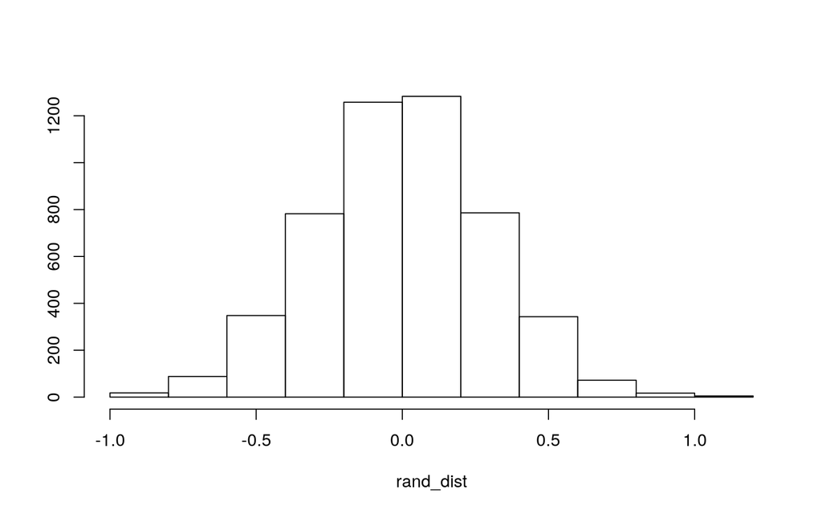

```r
{hist(rand_dist,main="",ylab=""); abline(v = c(-1.752466, 1.752466),col="red")}
```

- **3. (40 pts)** Build a linear regression model predicting one of your response variables from at least 2 other variables, including their interaction. Mean-center any numeric variables involved in the interaction.

```
- Interpret the coefficient estimates (do not discuss significance) (10)
- Plot the regression using `ggplot()` using geom_smooth(method="lm"). If your interaction is numeric by numeric, refer to code in the slides to make the plot or check out the `interactions` package, which makes this easier. If you have 3 or more predictors, just chose two of them to plot for convenience. (10)
- What proportion of the variation in the outcome does your model explain? (4)
- Check assumptions of linearity, normality, and homoskedasticity either graphically or using a hypothesis test (5)
- Regardless, recompute regression results with robust standard errors via `coeftest(..., vcov=vcovHC(...))`. Discuss significance of results, including any changes from before/after robust SEs if applicable. (10)
```

```r
library(sandwich); library(lmtest)
CollegeDistance$score_c <- CollegeDistance$score - mean(CollegeDistance$score)
CollegeDistance$wage_c <- CollegeDistance$wage - mean(CollegeDistance$wage)
fitcollege<-lm(score_c~gender*wage_c, data=CollegeDistance) #linear regression
summary(fitcollege)
```

```
##
## Call:
## lm(formula = score_c ~ gender * wage_c, data =
CollegeDistance)
##
## Residuals:
## Min 1Q Median 3Q Max
## -23.1706 -6.7752 0.2272 6.7482 21.5936
##
## Coefficients:
## Estimate Std. Error t value Pr(>|t|)
## (Intercept) -0.6135 0.1690 -3.630 0.000287 ***
## gendermale 1.3445 0.2516 5.344 9.54e-08 ***
## wage_c 0.5789 0.1252 4.625 3.84e-06 ***
## gendermale:wage_c 0.3666 0.1876 1.954 0.050742 .
## ---
## Signif. codes: 0 '***' 0.001 '**' 0.01 '*' 0.05 '.' 0.1
' ' 1
##
## Residual standard error: 8.616 on 4735 degrees of
freedom
## Multiple R-squared: 0.02032, Adjusted R-squared: 0.0197
## F-statistic: 32.74 on 3 and 4735 DF, p-value: < 2.2e-16
```

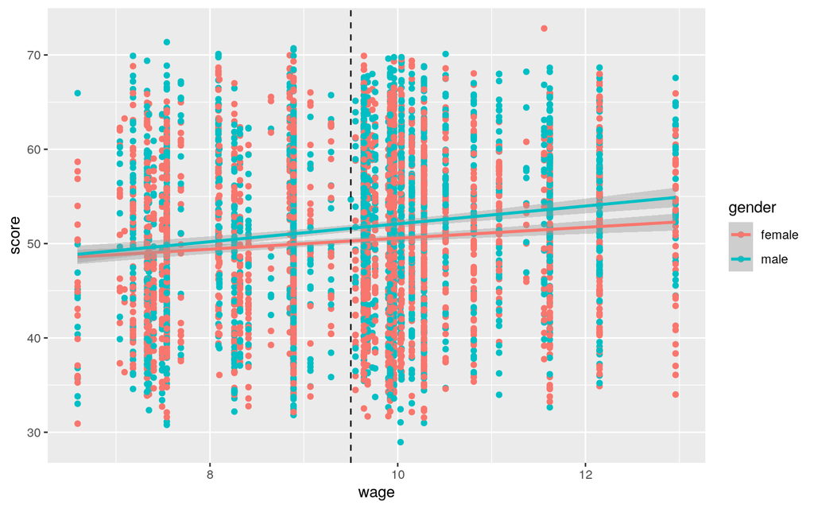

```r
CollegeDistance %>% select(score, wage, gender) %>% na.omit %>% ggplot(aes(wage, score, color=gender)) +
geom_point()+geom_smooth(method="lm") + geom_vline(xintercept=mean(CollegeDistance$wage,na.rm=T),lty=2)
```

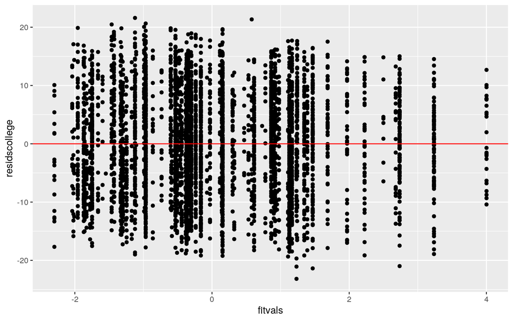

```r
residscollege<-fitcollege$residuals; fitvals<-fitcollege$fitted.values
ggplot()+geom_point(aes(fitvals,residscollege))+geom_hline(yintercept=0, col="red") #graph looking for linearity and homoskedasticity
```

```r
bptest(fitcollege) # null: homoskedastic
```

```
##
##  studentized Breusch-Pagan test
##
## data:  fitcollege
## BP = 20.493, df = 3, p-value = 0.0001342
```

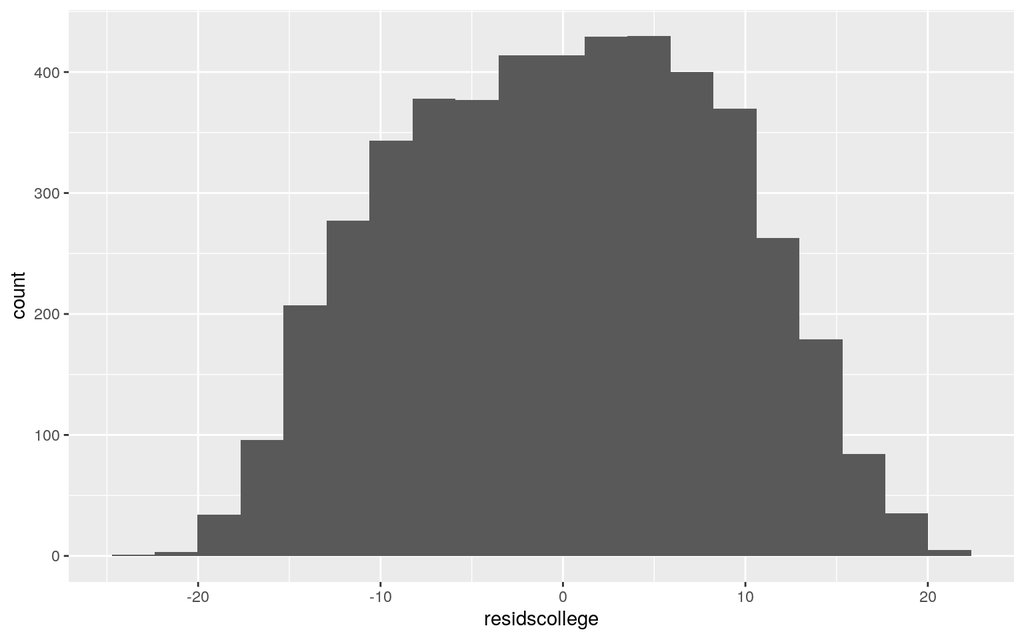

```r
ggplot()+geom_histogram(aes(residscollege), bins=20) #normality
```

```r
#corrected SE
coeftest(fitcollege, vcov = vcovHC(fitcollege))[,1:4]
```

```
## Estimate Std. Error t value Pr(>|t|)
## (Intercept) -0.6135079 0.1657800 -3.700735 2.174176e-04
## gendermale 1.3444705 0.2530834 5.312362 1.131730e-07
## wage_c 0.5788786 0.1212740 4.773310 1.866826e-06
## gendermale:wage_c 0.3665881 0.1848205 1.983481
4.737134e-02
```

- **4. (5 pts)** Rerun same regression model (with the interaction), but this time compute bootstrapped standard errors (either by resampling observations or residuals). Discuss any changes you observe in SEs and p-values using these SEs compared to the original SEs and the robust SEs)

The original and robust SEs are very similar, but the bootstrapped SEs values differ; the SE for females and males is much larger, the wage SE is smaller. The only SE that does not differ is for the slope of wage on score for males. This would mean that the p-values would also be adjusted using the bootstrapped SEs.

```r
boot_dat1<- sample_frac(CollegeDistance, replace=T)#sample rows from dataset
samp_distn<-replicate(5000, {
boot_dat1 <- sample_frac(CollegeDistance, replace=T) #take bootstrap sample of rows
fitcollege1 <- lm(score~wage*gender, data=boot_dat1) #fit model on bootstrap sample
coef(fitcollege1) #save coefs
})
## Estimated SEs
samp_distn %>% t %>% as.data.frame %>% summarize_all(sd)
```

```
##   (Intercept)     wage gendermale wage:gendermale
## 1    1.149925 0.120173   1.749998       0.1807798
```

- **5. (30 pts)** Fit a logistic regression model predicting a binary variable (if you don’t have one, make/get one) from at least two explanatory variables (interaction not necessary).
  - Interpret coefficient estimates in context (10)
  - Report a confusion matrix for your logistic regression (5)
  - Compute and discuss the Accuracy, Sensitivity (TPR), Specificity (TNR), Precision (PPV), and AUC of your model (5)
  - Using ggplot, make a density plot of the log-odds (logit) colored/grouped by your binary outcome variable (5)
  - Generate an ROC curve (plot) and calculate AUC (either manually or with a package); interpret (5)

```r
#Logistic Regression
CollegeDistance1<-CollegeDistance%>%mutate(y=ifelse(income=="high",1,0))
CollegeDistance1$income<-factor(CollegeDistance1$income,levels=c("high","low"))
fitClog<-glm(y~score+wage, data=CollegeDistance1, family="binomial")
coeftest(fitClog)
```

```
##
## z test of coefficients:
##
## Estimate Std. Error z value Pr(>|z|)
## (Intercept) -4.0870443 0.2978970 -13.7197 < 2.2e-16 ***
## score 0.0452659 0.0038767 11.6764 < 2.2e-16 ***
## wage 0.0885176 0.0244787 3.6161 0.0002991 ***
## ---
## Signif. codes: 0 '***' 0.001 '**' 0.01 '*' 0.05 '.' 0.1
' ' 1
```

```r
exp(coef(fitClog))
```

```
## (Intercept)       score        wage
##  0.01678878  1.04630600  1.09255349
```

```r
probs<-predict(fitClog,type="response")
#Confusion matrix
table(predict=as.numeric(probs>.5),truth=CollegeDistance1$y)%>%addmargins
```

```
##        truth
## predict    0    1  Sum
##     0   3368 1357 4725
##     1      6    8   14
##     Sum 3374 1365 4739
```

[figure not shown]

```r
#Density Plot
CollegeDistance1$logit<-predict(fitClog,type="link")
CollegeDistance1%>%ggplot()+geom_density(aes(logit,color=income,fill=income), alpha=.4)+
  theme(legend.position=c(.85,.85))+geom_vline(xintercept=0)+xlab("logit (log-odds)")+
  geom_rug(aes(logit,color=income))+
  geom_text(x=-5,y=.07,label="TN = 431")+
  geom_text(x=-1.75,y=.008,label="FN = 19")+
  geom_text(x=1,y=.006,label="FP = 13")+
  geom_text(x=5,y=.04,label="TP = 220")
```

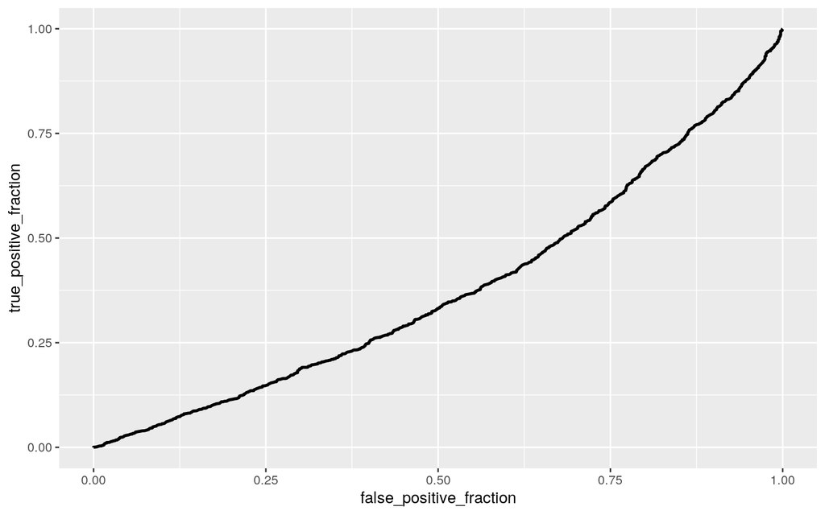

```r
#ROC curve and AUC
library(plotROC)
ROCplot<-ggplot(CollegeDistance1)+geom_roc(aes(d=income,m=probs), n.cuts=0)
ROCplot
```

```r
calc_auc(ROCplot)
```

```
##   PANEL group       AUC
## 1     1    -1 0.3812981
```

```r
(8+3368)/4739 #Accuracy
```

```
## [1] 0.7123866
```

```r
8/14 #Sensitivity (TPR)
```

```
## [1] 0.5714286
```

```r
3368/4725 #Specificity (TNR)
```

```
## [1] 0.7128042
```

```r
8/1365 #ppv (precision)
```

```
## [1] 0.005860806
```

- **6. (25 pts)** Perform a logistic regression predicting the same binary response variable from *ALL* of the rest of your variables (the more, the better!)
  - Fit model, compute in-sample classification diagnostics (Accuracy, Sensitivity, Specificity, Precision, AUC), and interpret (5)
  - Perform 10-fold (or repeated random sub-sampling) CV with the same model and report average out-of-sample classification diagnostics (Accuracy, Sensitivity, Specificity, Precision, and AUC); interpret AUC and compare with the in-sample metrics (10)
  - Perform LASSO on the same model/variables. Choose lambda to give the simplest model whose accuracy is near that of the best (i.e., `lambda.1se`). Discuss which variables are retained. (5)
  - Perform 10-fold CV using only the variables lasso selected: compare model’s out-of-sample AUC to that of your logistic regressions above (5)

For the logistic regression model on all of the rest of my variables, the accuracy is a value of 0.7647 which is a fair value, the sensitivity is 0.3802, specificity is 0.9203, precision is 0.6586 which could be better, and the AUC value is a fair value of 0.7502. In the 10-fold CV, the out-of-sample classification diagnostics are pretty similar to the original model. The classification diagnostics include: an accuracy of 0.7643, a sensitivity of 0.3781, specificity of 0.9208, precision of 0.6589 and an AUC value of 0.7461 which is still considered to be fair.

The variables retained or selected by LASSO were gender (female), ethnicity (other), fcollege (yes), mcollege (yes), home(yes), urban(yes), unemp, wage, distance, and education. The out-of-sample AUC in the 10-fold CV using only the selected lasso variables was 0.7465 which is very similar to the out-of-sample AUC in the 10-fold CV using all of the other variables as well as the AUC result from the original logistic ‘fitall’ model.

```r
library(lmtest)
drop.cols <- c('score_c', 'wage_c', 'logit', 'income')
CollegeDistance2<- CollegeDistance1 %>% select(-one_of(drop.cols))
fitall<-glm(y~., data=CollegeDistance2, family="binomial")
exp(coef(fitall))
```

```
## (Intercept) gendermale ethnicityhispanic ethnicityother
score
## 0.008321853 1.238578741 0.869806784 1.568268435
0.997219557
## fcollegeyes mcollegeyes homeyes urbanyes unemp
## 3.462886200 1.738802010 2.008210403 0.758720425
0.952722108
## wage distance tuition education regionwest
## 1.088648083 0.945352325 1.233303154 1.165782482
1.221237132
```

```r
coeftest(fitall)
```

```
##
## z test of coefficients:
##
## Estimate Std. Error z value Pr(>|z|)
## (Intercept) -4.7888704 0.4067643 -11.7731 < 2.2e-16 ***
## gendermale 0.2139645 0.0713048 3.0007 0.002694 **
## ethnicityhispanic -0.1394842 0.1405455 -0.9924 0.320979
## ethnicityother 0.4499721 0.1138378 3.9527 7.726e-05 ***
## score -0.0027843 0.0050022 -0.5566 0.577785
## fcollegeyes 1.2421024 0.0880066 14.1137 < 2.2e-16 ***
## mcollegeyes 0.5531964 0.1029664 5.3726 7.761e-08 ***
## homeyes 0.6972440 0.1088415 6.4060 1.493e-10 ***
## urbanyes -0.2761219 0.0926002 -2.9819 0.002865 **
## unemp -0.0484320 0.0150542 -3.2172 0.001295 **
## wage 0.0849366 0.0293211 2.8968 0.003770 **
## distance -0.0561976 0.0192724 -2.9160 0.003546 **
## tuition 0.2096961 0.1457061 1.4392 0.150102
## education 0.1533925 0.0224491 6.8329 8.322e-12 ***
## regionwest 0.1998644 0.1134489 1.7617 0.078118 .
## ---
## Signif. codes: 0 '***' 0.001 '**' 0.01 '*' 0.05 '.' 0.1
' ' 1
```

```r
prob<-predict(fitall,type="response")
class_diag <- function(probs,truth){
  #CONFUSION MATRIX: CALCULATE ACCURACY, TPR, TNR, PPV
  if(is.character(truth)==TRUE) truth<-as.factor(truth)
  if(is.numeric(truth)==FALSE & is.logical(truth)==FALSE) truth<-as.numeric(truth)-1
  tab<-table(factor(probs>.5,levels=c("FALSE","TRUE")),factor(truth, levels=c(0,1)))
  acc=sum(diag(tab))/sum(tab)
  sens=tab[2,2]/colSums(tab)[2]
  spec=tab[1,1]/colSums(tab)[1]
  ppv=tab[2,2]/rowSums(tab)[2]

#CALCULATE EXACT AUC
  ord<-order(probs, decreasing=TRUE)
  probs <- probs[ord]; truth <- truth[ord]
  TPR=cumsum(truth)/max(1,sum(truth))
  FPR=cumsum(!truth)/max(1,sum(!truth))
  dup <-c(probs[-1]>=probs[-length(probs)], FALSE)
  TPR <-c(0,TPR[!dup],1); FPR<-c(0,FPR[!dup],1)
  n <- length(TPR)
  auc <- sum( ((TPR[-1]+TPR[-n])/2) * (FPR[-1]-FPR[-n]))
  data.frame(acc,sens,spec,ppv,auc)
}
class_diag(prob,CollegeDistance2$y)
```

```
##         acc      sens      spec       ppv       auc
## 1 0.7647183 0.3802198 0.9202727 0.6586294 0.7501903
```

```r
#10-fold CV
set.seed(1234)
k=10

data<-CollegeDistance2[sample(nrow(CollegeDistance2)),]
folds<-cut(seq(1:nrow(CollegeDistance2)),breaks=k,labels=F)

diags<-NULL
for(i in 1:k){
  train<-data[folds!=i,]
  test<-data[folds==i,]

  truth<-test$y

  fit<-glm(y~., data=train, family="binomial")

  probs<-predict(fit,newdata = test,type="response")

  diags<-rbind(diags,class_diag(probs,truth))
}

summarize_all(diags,mean)
```

```
##         acc      sens      spec       ppv       auc
## 1 0.7642938 0.3781024 0.9208232 0.6588771 0.7461495
```

```r
#LASSO
library(glmnet)
set.seed(1234)

CollegeDistance2$ethnicity <- factor(CollegeDistance2$ethnicity)
CollegeDistance2$gender <- factor(CollegeDistance2$gender)
CollegeDistance2$fcollege <- factor(CollegeDistance2$fcollege)
CollegeDistance2$mcollege <- factor(CollegeDistance2$mcollege)
CollegeDistance2$home <- factor(CollegeDistance2$home)
CollegeDistance2$urban <- factor(CollegeDistance2$urban)
CollegeDistance2$region <- factor(CollegeDistance2$region)

head(model.matrix(y~-1+., data=CollegeDistance2))
```

```
## genderfemale gendermale ethnicityhispanic ethnicityother
score fcollegeyes mcollegeyes homeyes
## 1 0 1 0 1 39.15 1 0 1
## 2 1 0 0 1 48.87 0 0 1
## 3 0 1 0 1 48.74 0 0 1
## 4 0 1 0 0 40.40 0 0 1
## 5 1 0 0 1 40.48 0 0 0
## 6 0 1 0 1 54.71 0 0 1
## urbanyes unemp wage distance tuition education
regionwest
## 1 1 6.2 8.09 0.2 0.88915 12 0
## 2 1 6.2 8.09 0.2 0.88915 12 0
## 3 1 6.2 8.09 0.2 0.88915 12 0
## 4 1 6.2 8.09 0.2 0.88915 12 0
## 5 1 5.6 8.09 0.4 0.88915 13 0
## 6 1 5.6 8.09 0.4 0.88915 12 0
```

```r
y1 <- as.matrix(CollegeDistance2$y)
x <- model.matrix(y~ -1+., data=CollegeDistance2) # the -1 drops intercept/ref group
head(x); x<-scale(x) #scale the dataset first
```

```
## genderfemale gendermale ethnicityhispanic ethnicityother
score fcollegeyes mcollegeyes homeyes
## 1 0 1 0 1 39.15 1 0 1
## 2 1 0 0 1 48.87 0 0 1
## 3 0 1 0 1 48.74 0 0 1
## 4 0 1 0 0 40.40 0 0 1
## 5 1 0 0 1 40.48 0 0 0
## 6 0 1 0 1 54.71 0 0 1
## urbanyes unemp wage distance tuition education
regionwest
## 1 1 6.2 8.09 0.2 0.88915 12 0
## 2 1 6.2 8.09 0.2 0.88915 12 0
## 3 1 6.2 8.09 0.2 0.88915 12 0
## 4 1 6.2 8.09 0.2 0.88915 12 0
## 5 1 5.6 8.09 0.4 0.88915 13 0
## 6 1 5.6 8.09 0.4 0.88915 12 0
```

```r
cv<-cv.glmnet(x,y1,family="binomial")
lasso<-glmnet(x,y1,family="binomial",lambda=cv$lambda.1se)
coef(lasso)
```

```
## 16 x 1 sparse Matrix of class "dgCMatrix"
##                            s0
## (Intercept)       -1.00791220
## genderfemale      -0.02682041
## gendermale         .
## ethnicityhispanic  .
## ethnicityother     0.20625974
## score              .
## fcollegeyes        0.48721515
## mcollegeyes        0.15593827
## homeyes            0.17796563
## urbanyes          -0.01617994
## unemp             -0.03281234
## wage               0.03535459
## distance          -0.03066024
## tuition            .
## education          0.20802544
## regionwest         .
```

```r
#10-fold with selected LASSO variables
set.seed(1234)
k=10 #choose number of folds

CollegeDistance2<-CollegeDistance2 %>% mutate(genderfemale=ifelse(CollegeDistance2$gender=="female",1,0), gendermale=ifelse(CollegeDistance2$gender=="male",1,0))
CollegeDistance2<-CollegeDistance2 %>% mutate(ethnicityother=ifelse(CollegeDistance2$ethnicity=="other",1,0))
CollegeDistance2<-CollegeDistance2 %>% mutate(fcollegeyes=ifelse(CollegeDistance2$fcollege=="yes",1,0))
CollegeDistance2<-CollegeDistance2 %>% mutate(mcollegeyes=ifelse(CollegeDistance2$mcollege=="yes",1,0))
CollegeDistance2<-CollegeDistance2 %>% mutate(homeyes=ifelse(CollegeDistance2$home=="yes",1,0))
CollegeDistance2<-CollegeDistance2 %>% mutate(urbanyes=ifelse(CollegeDistance2$urban=="yes",1,0))
CollegeDistance2<-CollegeDistance2 %>% mutate(regionwest=ifelse(CollegeDistance2$region=="yes",1,0))

data1<-CollegeDistance2[sample(nrow(CollegeDistance2)),] #randomly order rows
folds<-cut(seq(1:nrow(CollegeDistance2)),breaks=k,labels=F) #create folds
diags<-NULL
for(i in 1:k){
## Create training and test sets
train<-data1[folds!=i,]
test<-data1[folds==i,]
truth<-test$y
## Train model on training set
fit<-glm(y~genderfemale+ethnicityother+fcollegeyes+mcollegeyes+homeyes+urbanyes+unemp+wage+distance+education,data=train,family="binomial")
probs<-predict(fit,newdata = test,type="response")
## Test model on test set (save all k results)
diags<-rbind(diags,class_diag(probs,truth))
}
diags%>%summarize_all(mean)
```

```
##         acc      sens      spec       ppv       auc
## 1 0.7651381 0.3825228 0.9202271 0.6599566 0.7464592
```

### Dataset Sources

- CollegeDistance https://vincentarelbundock.github.io/Rdatasets/datasets.html

…